# External merge and first insights

Michiel van Eldik

2021-04-04

# **Back to main**

Back to main

# **1. Load data and libraries**

```r
library(lubridate)
library(dplyr)
library(kableExtra)
library(sf)
library(sp)
library(rgdal)
library(spatialEco)
library(revgeo)
library(car)
library(koRpus)
```

```r
input <- read.csv("sp_3_derived_vars.csv")
```

```r
geo_sao_paolo_df <- input
```

# **2. Connect to shapefile to assign municiaplity to cases**

There are a few NAs for the coordinates. We’ll move on without them for now.

```r
print(nrow(geo_sao_paolo_df[is.na(geo_sao_paolo_df$centroid_lat),]))
```

```
## [1] 15
```

```r
geo_sao_paolo_df <- geo_sao_paolo_df[!is.na(geo_sao_paolo_df$centroid_lat),]
```

Turn them into coordinate system (or something)

```r
coordinates(geo_sao_paolo_df) = c('centroid_long', 'centroid_lat')
```

We are using the ‘regular’ reference system,

```r
# assign coordinate system
crs.geo1 = CRS("+proj=longlat")
proj4string(geo_sao_paolo_df) = crs.geo1
```

```r
# Load shapefile
# state map
sp_map_2 <- readOGR('sao_paulo.shp')
```

All data points distributed throughout the municipalities of Sao Paulo state.

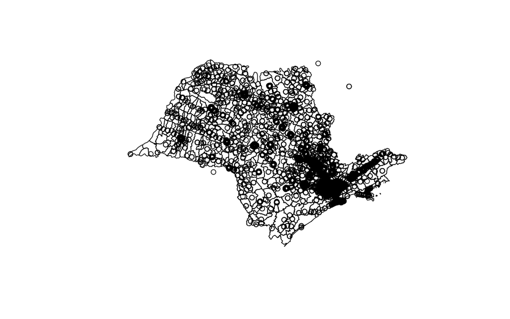

```r
plot(sp_map_2)
points(geo_sao_paolo_df)
```

Municipality name connected to original data

```r
# Connect shapefile polygon data on municipality classification with our point data
new_guy <- point.in.poly(geo_sao_paolo_df, sp_map_2)
```

```
## although coordinates are longitude/latitude, st_intersects assumes that they are planar
## although coordinates are longitude/latitude, st_intersects assumes that they are planar
```

```r
# transform it back to a normal dataframe in order to do further merging and analyses
new_guy_df <- as.data.frame(new_guy)
```

# **3. Incorporate municipality-level HDI**

```r
muni_hdi_sp_state <- read.csv('sp_state_municipalities_hdi.csv', header = FALSE)
```

Standardize data for merge

```r
# standardize words with weird Portuguese characters and accents
muni_hdi_sp_state$V1 <- iconv(muni_hdi_sp_state$V1, to = 'ASCII//TRANSLIT')
# to lower case
muni_hdi_sp_state$V1 <- tolower(muni_hdi_sp_state$V1)
```

Same for other data.

```r
# Unfortunately, there are still a bunch of NAs
new_guy_df$NOMEMUNICP <- iconv(new_guy_df$NOMEMUNICP, to = 'ASCII//TRANSLIT')
new_guy_df$NOMEMUNICP <- tolower(new_guy_df$NOMEMUNICP)
```

Merge!

```r
merry <- merge(new_guy_df,
               muni_hdi_sp_state,
               by.x = 'NOMEMUNICP',
               by.y = 'V1',
               all.x = TRUE)
```

# **4. First analyses**

## **4.1. Comparing HDI and commenting behaviour**

```r
bmod <- glm(title_or_message ~ log(V2), na.action=na.exclude, data = merry[merry$customer_city != 'sao paulo',], family = 'binomial')
print(summary(bmod))
```

```
##
## Call:
## glm(formula = title_or_message ~ log(V2), family = "binomial",
##     data = merry[merry$customer_city != "sao paulo", ], na.action = na.exclude)
##
## Deviance Residuals:
##    Min      1Q  Median      3Q     Max
## -1.237  -1.057  -1.017   1.297   1.408
##
## Coefficients:
##             Estimate Std. Error z value Pr(>|z|)
## (Intercept) -0.86010    0.07945 -10.825  < 2e-16 ***
## log(V2)     -2.24713    0.31268  -7.187 6.64e-13 ***
## ---
## Signif. codes:  0 '***' 0.001 '**' 0.01 '*' 0.05 '.' 0.1 ' ' 1
##
## (Dispersion parameter for binomial family taken to be 1)
##
##     Null deviance: 34464  on 25257  degrees of freedom
## Residual deviance: 34412  on 25256  degrees of freedom
##   (863 observations deleted due to missingness)
## AIC: 34416
##
## Number of Fisher Scoring iterations: 4
```

Interestingly there is a negative correlation between creation of reviews and human development index. That means a lower HDI leads to a higher probability of creating a review. There can be many explanations for this:

- Lower HDIs are prone to delays, causing more tardiness and more reviews.
- Expected delivery times are calculated with more ‘space’ because delivery times on these routes are more volatiles. In that case, there might be a lot of early deliveries, causing people to be happily surprised and commenting.
- HDI is related to product category, which in turn can be related to comment propensity.

**Interestingly** mean number of words is positively related to HDI if we take the non-respondents out of the equation.

```r
lmod <- lm(log(bef_nchar) ~ log(V2),
           na.action=na.exclude,
           data = merry[merry$bef_nchar > 0,])
print(summary(lmod))
```

```
##
## Call:
## lm(formula = log(bef_nchar) ~ log(V2), data = merry[merry$bef_nchar >
##     0, ], na.action = na.exclude)
##
## Residuals:
##     Min      1Q  Median      3Q     Max
## -3.2438 -0.5112  0.0958  0.6754  1.5280
##
## Coefficients:
##             Estimate Std. Error t value Pr(>|t|)
## (Intercept)   4.0640     0.0481  84.487  < 2e-16 ***
## log(V2)       0.8554     0.1984   4.311 1.64e-05 ***
## ---
## Signif. codes:  0 '***' 0.001 '**' 0.01 '*' 0.05 '.' 0.1 ' ' 1
##
## Residual standard error: 0.9317 on 16200 degrees of freedom
##   (367 observations deleted due to missingness)
## Multiple R-squared:  0.001146,   Adjusted R-squared:  0.001084
## F-statistic: 18.58 on 1 and 16200 DF,  p-value: 1.635e-05
```

Same for number of words.

```r
lmod <- lm(log(bef_nwords) ~ log(V2),
           na.action=na.exclude,
           data = merry[merry$bef_nchar > 0,])
print(summary(lmod))
```

```
##
## Call:
## lm(formula = log(bef_nwords) ~ log(V2), data = merry[merry$bef_nchar >
##     0, ], na.action = na.exclude)
##
## Residuals:
##      Min       1Q   Median       3Q      Max
## -2.17479 -0.50807  0.07972  0.71546  1.70240
##
## Coefficients:
##             Estimate Std. Error t value Pr(>|t|)
## (Intercept)  2.29913    0.04868   47.23  < 2e-16 ***
## log(V2)      0.83733    0.20082    4.17 3.07e-05 ***
## ---
## Signif. codes:  0 '***' 0.001 '**' 0.01 '*' 0.05 '.' 0.1 ' ' 1
##
## Residual standard error: 0.943 on 16200 degrees of freedom
##   (367 observations deleted due to missingness)
## Multiple R-squared:  0.001072,   Adjusted R-squared:  0.00101
## F-statistic: 17.39 on 1 and 16200 DF,  p-value: 3.067e-05
```

No evidence that HDI is related to average word length.

```r
lmod <- lm(log(nchar_perword) ~ log(V2),
           na.action=na.exclude,
           data = merry[merry$bef_nchar > 0,])
print(summary(lmod))
```

```
##
## Call:
## lm(formula = log(nchar_perword) ~ log(V2), data = merry[merry$bef_nchar >
##     0, ], na.action = na.exclude)
##
## Residuals:
##      Min       1Q   Median       3Q      Max
## -1.75986 -0.09770 -0.01116  0.09142  2.80338
##
## Coefficients:
##             Estimate Std. Error t value Pr(>|t|)
## (Intercept) 1.764876   0.009795 180.184   <2e-16 ***
## log(V2)     0.018026   0.040402   0.446    0.655
## ---
## Signif. codes:  0 '***' 0.001 '**' 0.01 '*' 0.05 '.' 0.1 ' ' 1
##
## Residual standard error: 0.1897 on 16200 degrees of freedom
##   (367 observations deleted due to missingness)
## Multiple R-squared:  1.229e-05,  Adjusted R-squared:  -4.944e-05
## F-statistic: 0.1991 on 1 and 16200 DF,  p-value: 0.6555
```

## **4.2. Other variables affecting review creation**

**Sao Paulo** is excluded as it is a huge city that should be looked at in more detail.

```r
bmod <- glm(message_bool ~ log(V2) + item_count + max_price + review_sent_wknd + review_score + log(diff_est_deliv + 176),
            na.action=na.exclude,
            data = merry[merry$customer_city != 'sao paulo',], family = 'binomial')
print(summary(bmod))
```

```
##
## Call:
## glm(formula = message_bool ~ log(V2) + item_count + max_price +
##     review_sent_wknd + review_score + log(diff_est_deliv + 176),
##     family = "binomial", data = merry[merry$customer_city !=
##         "sao paulo", ], na.action = na.exclude)
##
## Deviance Residuals:
##     Min       1Q   Median       3Q      Max
## -2.0505  -0.9427  -0.8618   1.3195   1.8971
##
## Coefficients:
##                             Estimate Std. Error z value Pr(>|z|)
## (Intercept)               -2.074e+00  1.224e+00  -1.695 0.090130 .
## log(V2)                   -2.301e+00  3.291e-01  -6.991 2.72e-12 ***
## item_count                 1.020e-01  2.623e-02   3.887 0.000101 ***
## max_price                  2.306e-04  7.722e-05   2.987 0.002820 **
## review_sent_wknd           8.427e-02  3.118e-02   2.702 0.006889 **
## review_score              -3.951e-01  1.162e-02 -33.998  < 2e-16 ***
## log(diff_est_deliv + 176)  4.968e-01  2.353e-01   2.111 0.034766 *
## ---
## Signif. codes:  0 '***' 0.001 '**' 0.01 '*' 0.05 '.' 0.1 ' ' 1
##
## (Dispersion parameter for binomial family taken to be 1)
##
##     Null deviance: 33043  on 24542  degrees of freedom
## Residual deviance: 31644  on 24536  degrees of freedom
##   (1578 observations deleted due to missingness)
## AIC: 31658
##
## Number of Fisher Scoring iterations: 4
```

```r
print(vif(bmod))
```

```
##                   log(V2)                item_count                 max_price
##                  1.001414                  1.015520                  1.003008
##          review_sent_wknd              review_score log(diff_est_deliv + 176)
##                  1.001029                  1.041410                  1.031892
```

Some interesting results already!

- Negative reviews make for higher creation probability
- Positive correlation between diff_est_deliv and review probability because a higher value for this variable implies there was a large difference between estimated delivery time and actual delivery time. I.e., being too late (too early are indicated with negative)
- V2 signifies HDI. Lower HDI means higher probability of review creation for some reason I don’t know yet. It’s opposite of what I expected.
- Higher prices and item counts elicite review creation.

Takeaways:

- The weird outcome for relationship between review creation and HDI can be due to the **age** factor. because younger people are more inclined to use the internet and low-HDI areas tend to have a lower age pyramid distribution.
- There are many deliveries that were reported in the comments as too late, but that are indicated in delivery data as on-time. It’s important to deal with this.
- In general, it’s important to be able to label what the topic of conversation is.

I plan to do this by building a text classifier that classifies whether a comment is frieght related by basing it on data that are confirmed to be delayed.

Moving on… Let’s have a look at product categories.

```r
bmod <- glm(message_bool ~ product_category_name,
            na.action=na.exclude,
            data = merry[merry$customer_city != 'sao paulo',], family = 'binomial')
print(summary(bmod))
```

```
##
## Call:
## glm(formula = message_bool ~ product_category_name, family = "binomial",
##     data = merry[merry$customer_city != "sao paulo", ], na.action = na.exclude)
##
## Deviance Residuals:
##     Min       1Q   Median       3Q      Max
## -1.4823  -1.0288  -0.9601   1.3168   1.9728
##
## Coefficients:
##                                                               Estimate
## (Intercept)                                                   -1.04145
## product_category_nameair_conditioning                          0.64614
## product_category_nameart                                       0.63599
## product_category_namearts_and_craftmanship                     1.04145
## product_category_nameaudio                                     0.76952
## product_category_nameauto                                      0.71949
## product_category_namebaby                                      0.39463
## product_category_namebed_bath_table                            0.84787
## product_category_namebooks_general_interest                    0.30575
## product_category_namebooks_imported                           -0.66329
## product_category_namebooks_technical                           0.45831
## product_category_namecds_dvds_musicals                       -11.52461
## product_category_namechristmas_supplies                        0.01980
## product_category_namecine_photo                                0.63599
## product_category_namecomputers                                 0.98083
## product_category_namecomputers_accessories                     0.63849
## product_category_nameconsoles_games                            0.60090
## product_category_nameconstruction_tools_construction           0.52016
## product_category_nameconstruction_tools_lights                 0.46609
## product_category_nameconstruction_tools_safety                 1.39813
## product_category_namecool_stuff                                0.78695
## product_category_namecostruction_tools_garden                  0.65199
## product_category_namecostruction_tools_tools                   0.94614
## product_category_namediapers_and_hygiene                       0.48184
## product_category_namedrinks                                    0.67749
## product_category_namedvds_blu_ray                              0.70498
## product_category_nameelectronics                               0.45885
## product_category_namefashio_female_clothing                    1.44692
## product_category_namefashion_bags_accessories                  0.68121
```

[output cut: 176 more lines]

```
## product_category_nametablets_printing_image                   0.91742
## product_category_nametelephony                                0.03095 *
## product_category_nametoys                                     0.06978 .
## product_category_namewatches_gifts                            0.02136 *
## ---
## Signif. codes:  0 '***' 0.001 '**' 0.01 '*' 0.05 '.' 0.1 ' ' 1
##
## (Dispersion parameter for binomial family taken to be 1)
##
##     Null deviance: 34534  on 25567  degrees of freedom
## Residual deviance: 34353  on 25499  degrees of freedom
##   (553 observations deleted due to missingness)
## AIC: 34491
##
## Number of Fisher Scoring iterations: 11
```

There is too muchgoing on to really say anything at this point. The data need to be classified into categorizations and then we can actually derive meaning from this. However, what is notable:

- **construction_tools_safety** is a relatively small (n = 56) category but seems to evoke comments quite strongly.
- **home_comfort** also is not a huge (n=174) category, but has a strong effect.
- Same story for **male clothing** that has only n = 48.

## **4.3. Other variables affecting review length**

```r
lmod <- lm(log(bef_nchar) ~ log(V2) + diff_rev_crea_ans + review_sent_wknd + max_price + review_answer_wknd + diff_est_deliv + top2box,
           na.action=na.exclude,
           data = merry[merry$bef_nchar > 0,])
print(summary(lmod))
```

```
##
## Call:
## lm(formula = log(bef_nchar) ~ log(V2) + diff_rev_crea_ans + review_sent_wknd +
##     max_price + review_answer_wknd + diff_est_deliv + top2box,
##     data = merry[merry$bef_nchar > 0, ], na.action = na.exclude)
##
## Residuals:
##     Min      1Q  Median      3Q     Max
## -3.6694 -0.4953  0.1272  0.6284  1.7168
##
## Coefficients:
##                      Estimate Std. Error t value Pr(>|t|)
## (Intercept)         4.393e+00  4.833e-02  90.896  < 2e-16 ***
## log(V2)             5.459e-01  1.924e-01   2.838  0.00455 **
## diff_rev_crea_ans   1.015e-03  7.883e-04   1.287  0.19795
## review_sent_wknd    1.156e-02  1.668e-02   0.693  0.48819
## max_price           1.654e-04  4.006e-05   4.129 3.66e-05 ***
## review_answer_wknd  9.708e-03  1.669e-02   0.582  0.56090
## diff_est_deliv      9.187e-04  8.032e-04   1.144  0.25269
## top2box            -6.630e-01  1.565e-02 -42.378  < 2e-16 ***
## ---
## Signif. codes:  0 '***' 0.001 '**' 0.01 '*' 0.05 '.' 0.1 ' ' 1
##
## Residual standard error: 0.8805 on 15408 degrees of freedom
##   (1153 observations deleted due to missingness)
## Multiple R-squared:  0.1089, Adjusted R-squared:  0.1085
## F-statistic: 269.1 on 7 and 15408 DF,  p-value: < 2.2e-16
```

```r
print(vif(lmod))
```

```
##            log(V2)  diff_rev_crea_ans   review_sent_wknd          max_price
##           1.004008           1.002051           1.064340           1.000635
## review_answer_wknd     diff_est_deliv            top2box
##           1.064428           1.035719           1.034970
```

Takeaways…

- Lower review scores elecit longer messages, accounting for the fact that “0” length messages are not in the equation.
- Higher priced products elicit longer messages.
- Higher HDI elicits longer messages.

## **4.4. Lexical diversity**

```r
library(koRpus.lang.en)
example_1 <- "hey jude"
example_2 <- "hey jude, dont make it bad"

available.koRpus.lang()

lex.div(example_1, force.lang= "en")
```

[output not shown]

# **5. Moving forward**

There is still a lot of work to do, especially in the area of categorizing comments; factoring things like ‘age’ into the equation; looking at other states; comparing urbanity; looking at neighborhood level; classifying products; etc.

What I’m thinking about the most is the negative statistical relationship between HDI and revieww creation and the positive relationship between HDI and review length. The **age distribution** account is something to explore. Moreover, this is an extremely limited analysis because it assumes one level of data whilst in actuality, we have nested data because we are using municipal-level data and individual-level data.

Be that as it may, we have a nice beginning. Even for a state like Sao Paulo, which has mostly municipalities on the higher end of the HDI spectrum, we can see that there is indeed enough variance to get to some interesting insights.